# Exercise 6

2022-02-20

**For this week’s assignment, I’ll guide you through:**

- **The construction of a cause-deleted life table**
- **The decomposition of a difference between life expectancies into age- and cause-specific components**

**For the cause-deleted life table, you’ll use the data from Russia in 1997 that we used in Exercise 5.**

**For the life expectancy difference decomposition, you’ll compare Russia to Japan in 1997.**

**For this assignment, we’re going to go on this journey together, so you can learn the ropes. But follow along closely… because you’ll be on your own doing similar tasks for the final!**

**Let’s do this.**

# Setup

```r
if (!require("pacman")) install.packages("pacman")
```

```r
# p_load function loads packages if installed, or install then loads otherwise
pacman::p_load(dplyr, ggplot2, knitr, kableExtra, readr)
```

# Data collection

```r
repo_url <- "https://github.com/hanowell/uwsoc533a-exercise-06"
rus_Mxi_Dxi <-
  readRDS(url(paste0(repo_url, "/blob/main/data/rus_Mxi_Dxi.rds?raw=true")))
jpn_Mxi_Dxi <-
  readRDS(url(paste0(repo_url, "/blob/main/data/jpn_Mxi_Dxi.rds?raw=true")))
```

# About the data

**You’ve just loaded age- and cause-specific mortality rates for Russia (`rus_Mxi_Dxi`) and Japan (`jpn_Mxi_Dxi`) in 1997. The data comes from the [Human Cause of Death Database](https://www.causesofdeath.org/cgi-bin/country.php?country=RUS). Specifically, I took the age-specific death rates for the so-called [short list](https://www.causesofdeath.org/docs/short_list.pdf) of causes of death. Then I differentiated heart disease mortality from all other causes.**

**The tables for both countries, respectively, have the following structure:**

- `x`**: the exact age at the beginning of the age group**
- `Mx_heart`**: observed period age-specific heart disease mortality rate per person-year**
- `Mx_other`**: observed period age-specific mortality rate due to all other causes, again per person-year**
- `Dx_heart`**: observed period age-specific number of deaths due to heart disease**
- `Dx_other`**: observed period age-specific number of deaths due to all other causes**

# 1 Construct a cause-deleted life table

**In this section, I’ll guide you through the construction of a cause-deleted life table for Russia in 1997.**

## 1.1 Preliminary basic questions about the goal of cause-deleted life table construction

**Recall the definition of a cause-deleted life table that we covered in class, available in the link below:**

https://hanowell.github.io/uwsoc533a/multiple-decrement-processes.html#associated-single-decrement-tables-from-period-data

### 1.1.1 Which rate will we use?

**Given this definition, which of the cause-specific mortality rates in `rus_Mxi_Dxi` will our cause-deleted life table use when constructing our associated decrement table?**

### 1.1.2 What is the hypothetical scenario we’re addressing?

**What hypothetical scenario will this cause-deleted life table help us to understand?**

## 1.2 Evaluate the tenability of the proportional hazards assumption

**To construct our cause-deleted life table, we’ll employ the proportional hazards assumption to address the challenge that $_n^*m_x^{-i}$ (the cause-specific mortality schedule under the cause-deleted life table’s hypothetical scenario) is not equal to $_nm_x^{-i}$ (the cohort age-specific decrement rate schedule in the presence of competing risks, which we are assuming is equal to the period age-specific decrement rate schedule $_nM_x^{-i}$) since the former removes all competing risks while the latter does not.**

**Remember, the proportional hazards assumption assumes that – within an age interval — there is a constant of proportionality $R^{i}$ between a cause-specific decrement rate $_nm_x^{i}$ and the all-cause decrement rate $_nm_x$.**

**Setting aside the cause-deleted life table case for the moment, consider instead an associated single decrement table that focuses on heart disease mortality.**

**Below is a plot of the cause-specific mortality rate from heart disease and the all-cause age-specific mortality rate. Based on this plot, over what age ranges is the proportional hazards assumption most suspect in the construction of an associated single decrement table for heart disease mortality, and why?**

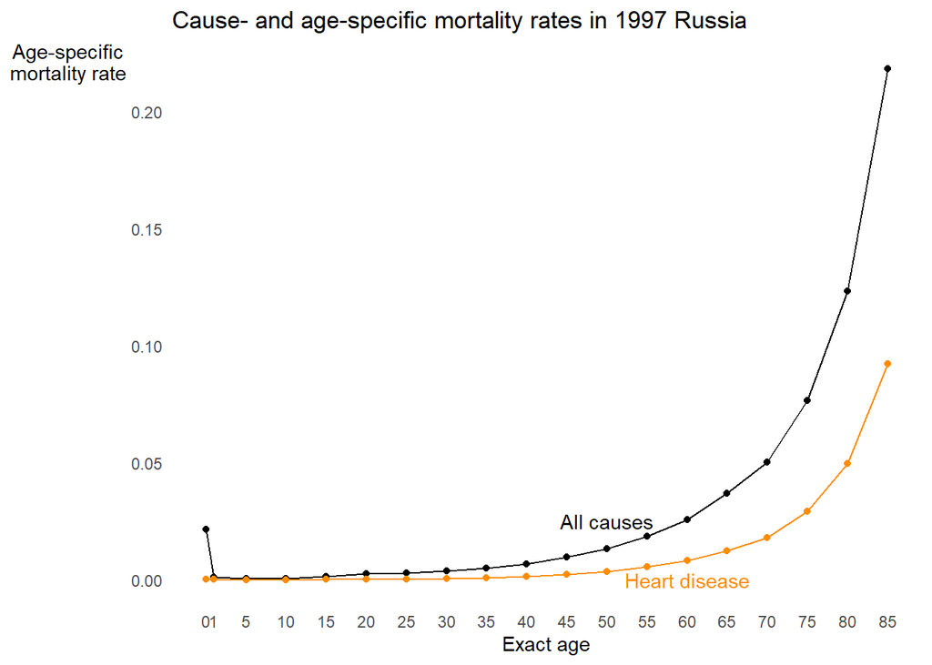

## 1.4 Calculate the age-specific constants of proportionality for each cause of death

**Using the statistics in the data set I gave you, calculate the constant of proportionality of interest for the cause-deleted life table for each age group, reporting it in a table below with the following structure:**

- `x`**: exact age at the start of the age interval**
- `Rx`**: the age-specific constant of proportionality of interest**

## 1.5 Use the constant of proportionality to ${}_n^*p_x^{-i}$ from ${}_np_x$

**Present the result in a table below with the following columns:**

- `x`**: exact age at the start of the age interval**
- `px`**: Within-interval probability of survival in the “parent life table”**
- `px_star`**Within-interval probability of survival in the cause-deleted life table**

## 1.6 Use ${}_n^*p_x^{-i}$ to calculate other columns in the cause-deleted life table

**Given only $_n^*p_x^{-i}$, consider what other columns in the cause-deleted life table that you can now complete. Remember: the cause-deleted life table is just a special kind of single decrement table. Present the results in a table below using column names inspired by my conversion of ${}_n^*p_x^{-i}$ to column name `px_star`.**

## 1.7 Compute ${}_n^*a_x^{-i}$

**Above, you filled in some of the columns in the cause-deleted life table, but there are others you can’t complete without knowing ${}_n^*a_x^{-i}$. Compute $_n^*a_x^{-i}$ for this cause-deleted life table with the following conventions:**

- **For $10 \leq x < 80$, use the graduation method via Keyfitz’s polynomial (Eq. 4.6 in PHG). Remember: You don’t have to iterate Keyfitz’s polynomial in this case because you can already calculated ${}_n^*d_x^{-i}$ directly (by the way, that’s a hint about part of the solution to the last problem).**
- **For $x < 10$ and closed intervals where $x \geq 80$, use the alternative method from PHG Eq. 4.8.**
- **For the open-ended interval, use $e^0 / R^{-i}$**

**Code up the calculation below but hold onto your results until the next section**

## 1.8 Compute the rest of the columns in the cause-deleted life table

**With ${}_n^*a_x^{-i}$ in hand, calculate the rest of the columns in the cause-deleted life table and present your results below using column names inspired by my conversion of ${}_n^*p_x^{-i}$ to column name `px_star`.**

**By the way, I’ll tell you right now that you’ll need to define ${}_n^*m_x^{-i}$ because (remember) it’s not the same as observed ${}_nm_x^{-i}$. But you have to figure out how to calculate it based on your understanding of age-specific rate definitions.**

## 1.9 Compute the effect of heart disease mortality on life expectancy at each age

**Using the “parent” life table and the cause-deleted life table, calculate the effect of heart disease mortality on life expectancyat each age. Report the results below in a table with the following structure:**

- `x`**: Exact age at the start of the interval**
- `ex_diff`**: The age-specific additive effect of heart disease mortality on life expectancy at age `x`**
- `ex_pdiff`**: The difference expressed as a percent of parent life table life expectancy**

## 1.10 Interpret the result

**In a few sentences, interpret the results of the table you calculated in the previous problem in light of the cause-specific patterns of mortality experience in Russia in 1997. It will help to look at all of your results so far.**

# 2 Age- and cause-specific composition of a difference between life expectancies

**In this section, you’ll decompose the difference in life expectancy between Japan and Russia, using Russia as the basis for comparison, i.e., you will decompose the difference:**

$$e_0^{\circ}\left(\text{JPN}\right) - e_0^{\circ}\left(\text{RUS}\right)$$

**I’ll guide you through the process this time, but again, follow along closely for when you’re on your own in the final.**

**The age- and cause-specific contribution to the difference between these two life expectancies is expressed below:**

$${}_n\Delta_x^i
= {}_n\Delta_x \cdot \frac{
{}_nm_x^i\left(\text{JPN}\right)
- {}_nm_x^i\left(\text{RUS}\right)
}
{
{}_nm_x\left(\text{JPN}\right)
- {}_nm_x\left(\text{RUS}\right)
}$$

**Remember that in this case ${}_n\Delta_x$ represents the age-specific difference in LIFE EXPECTANCY (what we learned in chapter 3). It DOES NOT represent the age-specific difference in crude death rate (what we learned in chapter 2).**

## 2.1 Calculate the all-cause single decrement table for Japan

**Using the same assumptions as for Russia’s all-cause single decrement table, write the code and then display the life table below:**

### 2.1.1 Calculate ${}_n\Delta_x$

**Using the methods we learned in chapter 3, calculate the age-specific contributions to the life expectancy difference of interest, displaying the results in a table below with the following structure:**

- `x`**: Exact age at the beginning of the age interval**
- `Deltax`**: The age-specific contribution to the life expectancy difference of interest**

### 2.1.2 Interpret the ${}_n\Delta_x$ results

**In a few sentences below, describe the key patterns you observe in the age-specific difference contributions you just calculated.**

## 2.2 Calculate the age- and cause-specific contributions to the difference

### 2.2.1 Calculate the cause-specific contributions for each age group

**Below, write the code to calculate the decomposition and display it in a table with the following structure:**

- `x`**: Exact age at the beginning of the age interval**
- `Deltax`**: Age-specific contribution to the life expectancy difference**
- `d_Mx_[h/o]`**: Two columns showing the difference in the age- and cause-specific mortality rates for the corresponding cause (h = heart, o = all other causes)**
- `d_Mx`**: The difference in the all-cause age-specific mortality rates**
- `Deltax_[h/o]`**: Two columns showing the age- and cause-specific contribution to the life expectancy for the corresponding cause (h = heart, o = all other causes)**

### 2.2.2 Calculate the total cause-specific contributions across all age groups

**Below, write the code to calculate the cause-specific contributions from the age- and cause-specific contributions and display it in a table below with the following structure:**

- `Delta_[heart/other]`**: Two columns showing the total cause-specific contributions due to heart disease (heart) and all other causes (other), respectively**

### 2.2.3 Calculate the total difference from the cause-specific contributions

**Using only your answer in the previous problem (and not the respective life expectancy values themselves), calculate the total difference in life expectancy between Japan and Russia in 1997.**

## 2.3 Interpret the decomposition results

### 2.3.1 Explain the total cause-specific contributions

**In a sentence below, explain how differences in heart disease mortality contribute in total to the difference in life expectancy between Japan and Russia.**

### 2.3.2 Explain the sign of a single age- and cause-specific contribution

**Look at the age- and cause-specific contribution of heart disease for persons aged 50 to 55. With reference to the age-specific contribution ${}_n\Delta_x$, the differences between the age-specific mortality rates due to heart disease, and the differences between the all-cause age-specific mortality rates, explain why the age- and cause-specific contribution takes the sign (positive or negative) that it does.**

### 2.3.3 Explain an age- and cause-specific contribution in words

**Remember that:**

$$e_0^\circ\left(\text{JPN}\right) - e_0^\circ\left(\text{RUS}\right)
= \sum_a \Delta_a = \sum_a \sum_i \Delta_a^i$$

**where age group is indexed by $a$ (to allow for varying age interval length $n$) and cause is indexed by $i$.**

**With that in mind, explain in words what the age- and cause-specific contribution of heart disease for persons aged 50 to 55 means.**

# Grading

**Every task you will complete in this assignment is worth the same number of points that total up to 7 points for the whole exercise. I will give half credit where you get the steps mostly right but the wrong numeric answer. For a good faith effort at full completion of the assignment, you get an extra half point.**